# EE658/758 Machine Learning in Engineering

## Assignment-2: Logistic Regression

## Part A: Logistic Regression with Scikit-learn

- **Load the dataset and split it into training and testing subsets.**
- **Use the scikit-learn library to develop a logistic regression model based on the training data. Use only Feature1 and Feature2.**
- **Plot the data points and the decision boundary of the model.**
- **Evaluate the model on the testing data and report its accuracy**

```python
import os
import numpy as np
import pandas as pd
import seaborn as sns
import matplotlib.pyplot as plt

from sklearn.preprocessing import StandardScaler
from sklearn.linear_model import LogisticRegression
from sklearn.model_selection import train_test_split
from mlxtend.plotting import plot_decision_regions
from sklearn.decomposition import PCA

from sklearn.metrics import accuracy_score, classification_report, confusion_matrix, f1_score
```

```python
# Load the dataset
data = pd.read_csv('data.csv', names=['Feature1', 'Feature2', 'Label'])
```

```python
# Split the dataset into features and labels
X = data[['Feature1', 'Feature2']]
y = data['Label']
```

```python
# Split the data into training and testing sets
X_train, X_test, y_train, y_test = train_test_split(X, y, test_size=0.2, random_state=42)
```

```python
# Create and train a logistic regression model
model = LogisticRegression()
model.fit(X_train, y_train)
```

```
LogisticRegression()
```

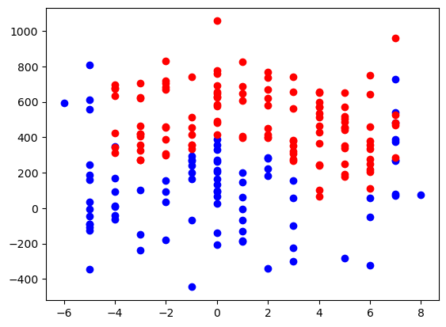

```python
# Plot the data points
plt.scatter(data[data['Label'] == 0]['Feature1'], data[data['Label'] == 0]['Feature2'], color='blue', label='Label 0')
plt.scatter(data[data['Label'] == 1]['Feature1'], data[data['Label'] == 1]['Feature2'], color='red', label='Label 1')
```

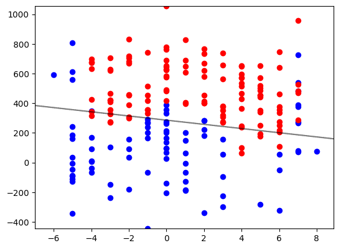

```python
# Plot the decision boundary
x_min, x_max = data['Feature1'].min() - 1, data['Feature1'].max() + 1
y_min, y_max = data['Feature2'].min() - 1, data['Feature2'].max() + 1
xx, yy = np.meshgrid(np.arange(x_min, x_max, 0.1), np.arange(y_min, y_max, 0.1))
Z = model.predict(np.c_[xx.ravel(), yy.ravel()])
Z = Z.reshape(xx.shape)
plt.contour(xx, yy, Z, colors='k', levels=[0.5], alpha=0.5)
# Plot the data points
plt.scatter(data[data['Label'] == 0]['Feature1'], data[data['Label'] == 0]['Feature2'], color='blue', label='Label 0')
plt.scatter(data[data['Label'] == 1]['Feature1'], data[data['Label'] == 1]['Feature2'], color='red', label='Label 1')
```

```python
# Evaluate the model
y_pred = model.predict(X_test)
accuracy = accuracy_score(y_test, y_pred)
print("Accuracy of the logistic regression model: {:.2f}%".format(accuracy * 100))
```

```
Accuracy of the logistic regression model: 90.00%
```

## Part B: Logistic Regression Without Scikit-learn

- **Implement logistic regression from scratch.**
- **Use the same training and testing data splits as in Part A.**
- **Develop a logistic regression model based on the training data, using only Feature1 and Feature2**
- **Display the cost (loss) as a function of iterations during the training process.**
- **Plot the data points and the decision boundary of your model**
- **Evaluate the model on the testing data and report its accuracy.**

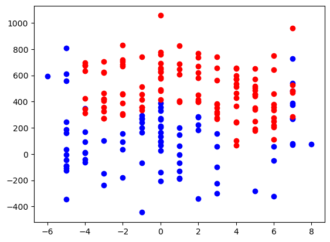

```python
# Plot the data points
plt.scatter(data[data['Label'] == 0]['Feature1'], data[data['Label'] == 0]['Feature2'], color='blue', label='Label 0')
plt.scatter(data[data['Label'] == 1]['Feature1'], data[data['Label'] == 1]['Feature2'], color='red', label='Label 1')
```

```python
# Sigmoid function
def sigmoid(z):
    return 1 / (1 + np.exp(-z))
```

```python
# Loss function (binary cross-entropy)
def compute_loss(y, y_pred):
    return -np.mean(y * np.log(y_pred) + (1 - y) * np.log(1 - y_pred))
```

```python
# Gradient descent
def gradient_descent(X, y, learning_rate, num_iterations):
    m, n = X.shape
    # Initialize weights and bias
    theta = np.zeros(n)
    bias = 0

    # Gradient descent loop
    losses = []
    for i in range(num_iterations):
        # Compute predictions
        z = np.dot(X, theta) + bias
        y_pred = sigmoid(z)

        # Compute gradients
        dz = y_pred - y
        dw = np.dot(X.T, dz) / m
        db = np.sum(dz) / m

        # Update parameters
        theta -= learning_rate * dw
        bias -= learning_rate * db

        # Compute loss
        loss = compute_loss(y, y_pred)
        losses.append(loss)

        if i % 100 == 0:
            print(f"Iteration {i}, Loss: {loss}")

    return theta, bias, losses
```

```python
# Predict function
def predict(X, theta, bias):
    z = np.dot(X, theta) + bias
    return np.round(sigmoid(z))
```

```python
# Split the data into training and testing sets
X_train, X_test, y_train, y_test = train_test_split(X, y, test_size=0.2, random_state=42)

# Scale the features using StandardScaler
scaler = StandardScaler()
X_train_scaled = scaler.fit_transform(X_train)
X_test_scaled = scaler.transform(X_test)

# Add intercept term to X
X_train_scaled = np.c_[np.ones((X_train_scaled.shape[0], 1)), X_train_scaled]
X_test_scaled = np.c_[np.ones((X_test_scaled.shape[0], 1)), X_test_scaled]
```

```python
# Hyperparameters
learning_rate = 0.01
num_iterations = 1000
```

```python
# Train logistic regression model
theta, bias, losses = gradient_descent(X_train_scaled, y_train, learning_rate, num_iterations)
```

```
Iteration 0, Loss: 0.6931471805599453
Iteration 100, Loss: 0.5975965937157713
Iteration 200, Loss: 0.5402994198219325
Iteration 300, Loss: 0.5038996092740937
Iteration 400, Loss: 0.47948267949345763
Iteration 500, Loss: 0.46234836597098977
Iteration 600, Loss: 0.4498801595640768
Iteration 700, Loss: 0.4405384565115448
Iteration 800, Loss: 0.43337120877280544
Iteration 900, Loss: 0.4277639513786845
```

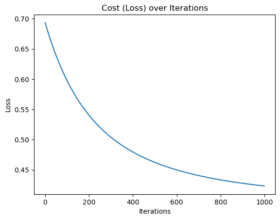

```python
# Plot cost over iterations
plt.plot(range(num_iterations), losses)
plt.xlabel('Iterations')
plt.ylabel('Loss')
plt.title('Cost (Loss) over Iterations')
plt.show()
```

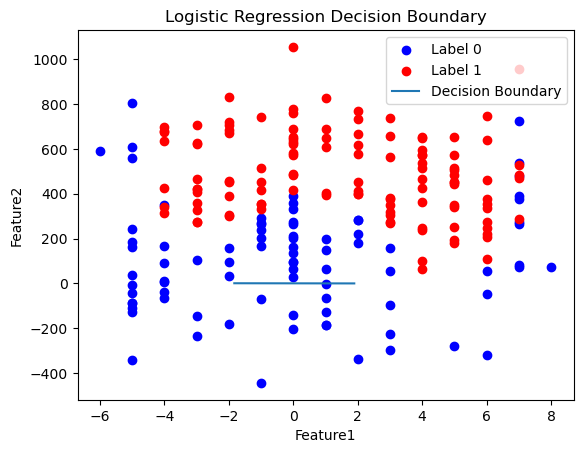

```python
# Plot the data points
plt.scatter(data[data['Label'] == 0]['Feature1'], data[data['Label'] == 0]['Feature2'], color='blue', label='Label 0')
plt.scatter(data[data['Label'] == 1]['Feature1'], data[data['Label'] == 1]['Feature2'], color='red', label='Label 1')

# Plot the decision boundary
x_values = [np.min(X_train_scaled[:, 1]), np.max(X_train_scaled[:, 1])]
y_values = -(theta[0] + np.dot(theta[1], x_values)) / theta[2]
plt.plot(x_values, y_values, label='Decision Boundary')

# Set plot labels and legend
plt.xlabel('Feature1')
plt.ylabel('Feature2')
plt.title('Logistic Regression Decision Boundary')
plt.legend()

# Show plot
plt.show()
```

```python
# Evaluate the model
y_pred_train = predict(X_train_scaled, theta, bias)
accuracy_train = accuracy_score(y_train, y_pred_train)
print("Accuracy of the logistic regression model on training data: {:.2f}%".format(accuracy_train * 100))

y_pred_test = predict(X_test_scaled, theta, bias)
accuracy_test = accuracy_score(y_test, y_pred_test)
print("Accuracy of the logistic regression model on testing data: {:.2f}%".format(accuracy_test * 100))
```

```
Accuracy of the logistic regression model on training data: 85.00%
Accuracy of the logistic regression model on testing data: 90.00%
```

### Part C: Logistic Regression with Feature Engineering (Scikit-learn)

- **Enhance your dataset by adding new features that are at a higher degree of one of the original features (e.g., Feature1^2, Feature1 * Feature2).**
- **Use the scikit-learn library to develop a logistic regression model based on the enhanced training data.**
- **Plot the data points and the decision boundary of the model.**
- **Evaluate the model on the testing data and report its accuracy.**

```python
data['Feature_Product'] = data['Feature1'] * data['Feature2']
data['Feature_Add'] = data['Feature1'] + data['Feature2']
data['Feature_Divide'] = data['Feature1'] / data['Feature2']

# Update X with the new features
X = data[['Feature1', 'Feature2', 'Feature_Product', 'Feature_Add', 'Feature_Divide']]
Y = data["Label"]
# Split the data into training and testing sets
X_train, X_test, y_train, y_test = train_test_split(X, Y, test_size=0.20, random_state=42)
```

```python
# Create and train a logistic regression model
model = LogisticRegression()
model.fit(X_train, y_train)
```

```
LogisticRegression()
```

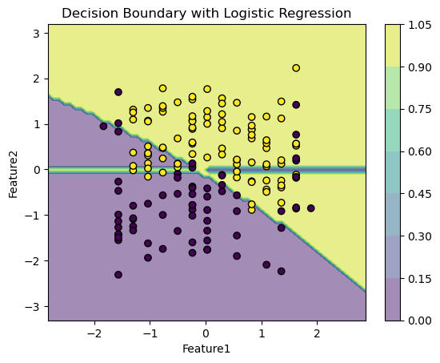

```python
def plot_decision_boundary(X, y, model):
    # Define the grid boundaries for the plot
    x_min, x_max = X[:, 0].min() - 1, X[:, 0].max() + 1
    y_min, y_max = X[:, 1].min() - 1, X[:, 1].max() + 1
    xx, yy = np.meshgrid(np.arange(x_min, x_max, 0.1),
                         np.arange(y_min, y_max, 0.1))

    # Prepare grid to be used in model prediction
    grid = np.c_[xx.ravel(), yy.ravel()]
    grid_features = np.c_[grid[:, 0] * grid[:, 1],  # Feature_Product
                          grid[:, 0] + grid[:, 1],  # Feature_Add
                          np.divide(grid[:, 0], grid[:, 1], out=np.zeros_like(grid[:, 0]), where=grid[:, 1]!=0)]  # Feature_Divide, handling division by zero

    # Combine original grid features with the additional ones for prediction
    grid_combined = np.hstack((grid, grid_features))

    # Predict using the logistic regression model
    Z = model.predict(grid_combined)
    Z = Z.reshape(xx.shape)

    # Plot the decision boundary
    plt.contourf(xx, yy, Z, alpha=0.5)
    plt.colorbar()
    plt.scatter(X[:, 0], X[:, 1], c=y, edgecolors='k')

    plt.xlabel('Feature1')
    plt.ylabel('Feature2')
    plt.title('Decision Boundary with Logistic Regression')
    plt.show()

# Ensure your data is scaled if your model was trained on scaled data
scaler = StandardScaler()
X_train_scaled = scaler.fit_transform(X_train)

# Train your logistic regression model if not already done
model = LogisticRegression()
model.fit(X_train_scaled, y_train)

# Plot using the first two features for visualization
plot_decision_boundary(X_train_scaled[:, :2], y_train, model)
```

```python
# Evaluate the model
y_pred = model.predict(X_test)
accuracy = accuracy_score(y_test, y_pred)
print("Accuracy of the logistic regression model: {:.2f}%".format(accuracy * 100))
```

```
Accuracy of the logistic regression model: 72.50%
```

### Part D: Logistic Regression with Feature Engineering (Without Scikit-learn)

- **Use the enhanced dataset from Part C.**
- **Implement logistic regression from scratch to develop a model based on the enhanced training data.**
- **Display the cost (loss) as a function of iterations during the training process.**
- **Plot the data points and the decision boundary of your model.**
- **Evaluate the model on the testing data and report its accuracy.**

```python
# Scale the features using StandardScaler
scaler = StandardScaler()
X_train_scaled = scaler.fit_transform(X_train)
X_test_scaled = scaler.transform(X_test)

# Add intercept term to X
X_train_scaled = np.c_[np.ones((X_train_scaled.shape[0], 1)), X_train_scaled]
X_test_scaled = np.c_[np.ones((X_test_scaled.shape[0], 1)), X_test_scaled]
```

```python
# Sigmoid function
def sigmoid(z):
    return 1 / (1 + np.exp(-z))

# Loss function (binary cross-entropy)
def compute_loss(y, y_pred):
    return -np.mean(y * np.log(y_pred) + (1 - y) * np.log(1 - y_pred))

# Gradient descent
def gradient_descent(X, y, learning_rate, num_iterations):
    m, n = X.shape
    # Initialize weights and bias
    theta = np.zeros(n)
    bias = 0

    # Gradient descent loop
    losses = []
    for i in range(num_iterations):
        # Compute predictions
        z = np.dot(X, theta) + bias
        y_pred = sigmoid(z)

        # Compute gradients
        dz = y_pred - y
        dw = np.dot(X.T, dz) / m
        db = np.sum(dz) / m

        # Update parameters
        theta -= learning_rate * dw
        bias -= learning_rate * db

        # Compute loss
        loss = compute_loss(y, y_pred)
        losses.append(loss)

        if i % 100 == 0:
            print(f"Iteration {i}, Loss: {loss}")

    return theta, bias, losses

# Hyperparameters
learning_rate = 0.01
num_iterations = 1000

# Train logistic regression model
theta, bias, losses = gradient_descent(X_train_scaled, y_train, learning_rate, num_iterations)
```

```
Iteration 0, Loss: 0.6931471805599453
Iteration 100, Loss: 0.5431848196857828
Iteration 200, Loss: 0.4819073125256529
Iteration 300, Loss: 0.4518157668643575
Iteration 400, Loss: 0.434978714234764
Iteration 500, Loss: 0.42469450802366
Iteration 600, Loss: 0.41801546938615547
Iteration 700, Loss: 0.4134784640378502
Iteration 800, Loss: 0.41028902783151383
Iteration 900, Loss: 0.40798529290494956
```

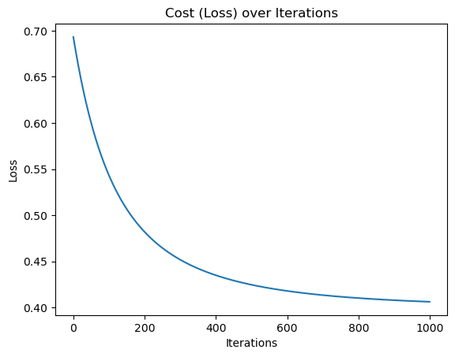

```python
# Plot cost over iterations
plt.plot(range(num_iterations), losses)
plt.xlabel('Iterations')
plt.ylabel('Loss')
plt.title('Cost (Loss) over Iterations')
plt.show()
```

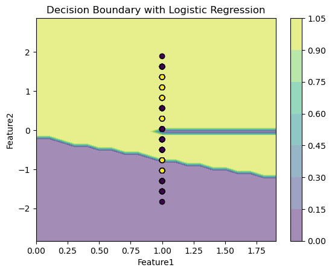

```python
def plot_decision_boundary(X, y, theta, bias):
    # Define the grid boundaries for the plot
    x_min, x_max = X[:, 0].min() - 1, X[:, 0].max() + 1
    y_min, y_max = X[:, 1].min() - 1, X[:, 1].max() + 1
    xx, yy = np.meshgrid(np.arange(x_min, x_max, 0.1),
                         np.arange(y_min, y_max, 0.1))

    # Prepare grid to be used in model prediction
    grid = np.c_[xx.ravel(), yy.ravel()]
    grid_features = np.c_[grid[:, 0] * grid[:, 1],  # Feature_Product
                          grid[:, 0] + grid[:, 1],  # Feature_Add
                          np.divide(grid[:, 0], grid[:, 1], out=np.zeros_like(grid[:, 0]), where=grid[:, 1]!=0)]  # Feature_Divide, handling division by zero

    # Combine original grid features with the additional ones for prediction
    grid_combined = np.hstack((np.ones((grid.shape[0], 1)), grid, grid_features))

    # Predict using the logistic regression model
    Z = predict(grid_combined, theta, bias)
    Z = Z.reshape(xx.shape)

    # Plot the decision boundary
    plt.contourf(xx, yy, Z, alpha=0.5)
    plt.colorbar()
    plt.scatter(X[:, 0], X[:, 1], c=y, edgecolors='k')

    plt.xlabel('Feature1')
    plt.ylabel('Feature2')
    plt.title('Decision Boundary with Logistic Regression')
    plt.show()


# Assuming 'data' is your DataFrame, 'theta' and 'bias' are your model's parameters
plot_decision_boundary(X_train_scaled, y_train, theta, bias)
```

```python
# Predict on training and testing sets
y_pred_train = predict(X_train_scaled, theta, bias)
accuracy_train = accuracy_score(y_train, y_pred_train)
print(f"Accuracy of the logistic regression model on training data: {accuracy_train * 100:.2f}%")

y_pred_test = predict(X_test_scaled, theta, bias)
accuracy_test = accuracy_score(y_test, y_pred_test)
print(f"Accuracy of the logistic regression model on testing data: {accuracy_test * 100:.2f}%")
```

```
Accuracy of the logistic regression model on training data: 85.62%
Accuracy of the logistic regression model on testing data: 90.00%
```